# Final_M

## TOP CHARACTERS HIGHEST STRENGTH MARVEL AND DC

[figure not shown]

```r
marvelDcStrength <- marvelDc %>%
  group_by(Name, Publisher) %>%
  distinct(Strength) %>%
  select(Name, Strength) %>%
  arrange(-Strength)
# Top 30 characters
top30 <- marvelDcStrength[20:50, ]

ggplot(top30, aes(x = reorder(Name, Strength), y = Strength, fill = Publisher)) +
  geom_col(width = 0.7, color = "black") +
  labs(x = "Character", y = "Strength",
       title = "Top 30 Marvel and DC Characters",
       subtitle = "With Highest Strength") +
  theme_minimal() +
  scale_fill_manual(values = dcMarvelPalette) +
  coord_flip() +
  theme(axis.text.y = element_text(size = 10, face = "bold"),
        axis.title = element_text(size = 12, face = "bold"),
        plot.title = element_text(size = 16, face = "bold"),
        plot.subtitle = element_text(size = 14, face = "italic"))
```

### Alternate

The plot displays the characters’ strength frequencies and distinguishes between Marvel and DC characters using different colors.

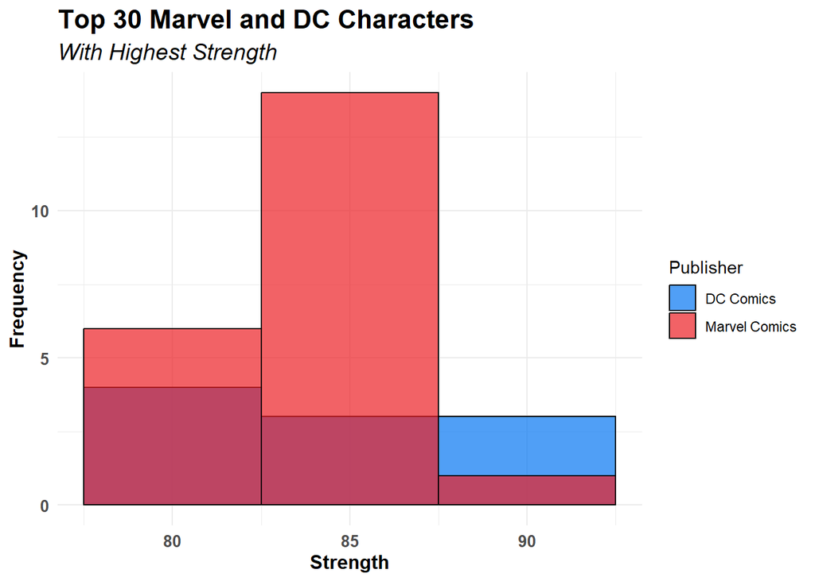

```r
top30 <- marvelDcStrength[30:60, ]

ggplot(top30, aes(x = Strength, fill = Publisher)) +
  geom_histogram(binwidth = 5, color = "black", alpha = 0.7, position = "identity") +
  labs(x = "Strength", y = "Frequency",
       title = "Top 30 Marvel and DC Characters",
       subtitle = "With Highest Strength") +
  theme_minimal() +
  scale_fill_manual(values = dcMarvelPalette) +
  theme(axis.text = element_text(size = 10, face = "bold"),
        axis.title = element_text(size = 12, face = "bold"),
        plot.title = element_text(size = 16, face = "bold"),
        plot.subtitle = element_text(size = 14, face = "italic"))
```

# TOP CHARACTERS HIGHEST SPEED MARVEL AND DC

[figure not shown]

```r
# TOP CHARACTERS HIGHEST SPEED MARVEL AND DC

marvelDcSpeed <- marvelDc %>%
  group_by(Name, Publisher) %>%
  distinct(Speed) %>%
  select(Name, Speed) %>%
  arrange(-Speed)
ggplot(marvelDcSpeed[1:30, ], aes(x = reorder(Name, Speed), y = Speed)) +
  geom_bar(stat = "identity", aes(fill = Publisher)) +
  labs(x = "Character", y = "Speed", title = "Top 30 Marvel and DC Characters", subtitle = "With Highest Speed") +
  coord_flip() +
  theme_bw() +
  scale_fill_manual(values=dcMarvelPalette)
```

### Alternate

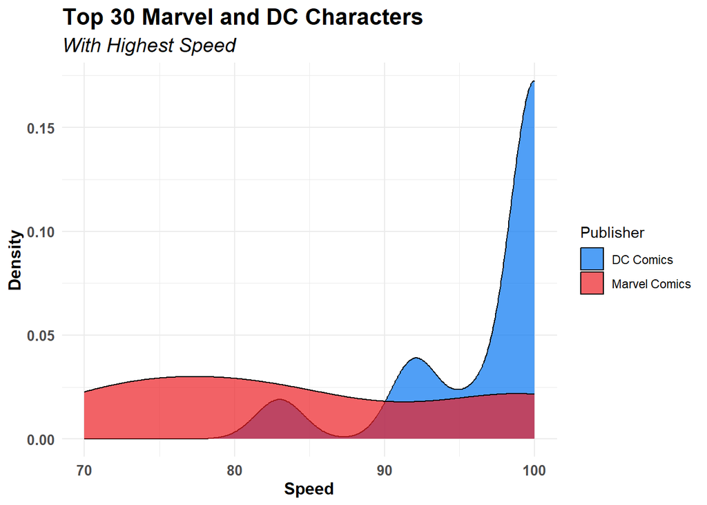

```r
marvelDcSpeed <- marvelDc %>%
  group_by(Name, Publisher) %>%
  distinct(Speed) %>%
  select(Name, Speed) %>%
  arrange(-Speed)
# Create a density plot
ggplot(marvelDcSpeed[1:30, ], aes(x = Speed, fill = Publisher)) +
  geom_density(alpha = 0.7) +
  labs(x = "Speed", y = "Density",
       title = "Top 30 Marvel and DC Characters",
       subtitle = "With Highest Speed") +
  theme_minimal() +
  scale_fill_manual(values = dcMarvelPalette) +
  theme(axis.text = element_text(size = 10, face = "bold"),
        axis.title = element_text(size = 12, face = "bold"),
        plot.title = element_text(size = 16, face = "bold"),
        plot.subtitle = element_text(size = 14, face = "italic"))
```

## TOP CHARACTERS HIGHEST DURABILITY MARVEL AND DC

[figure not shown]

```r
# TOP CHARACTERS HIGHEST DURABILITY MARVEL AND DC

marvelDcDur <- marvelDc %>%
  group_by(Name, Publisher) %>%
  distinct(Durability) %>%
  select(Name, Durability) %>%
  arrange(-Durability)
ggplot(marvelDcDur[1:30, ], aes(x = reorder(Name, Durability), y = Durability)) +
  geom_bar(stat = "identity", aes(fill = Publisher)) +
  ylim(0, 120) +
  labs(x = "Character", y = "Durability", title = "Top 30 Marvel and DC Characters", subtitle = "With Highest Durability") +
  coord_flip() +
  theme_bw() +
  scale_fill_manual(values=dcMarvelPalette)
```

### Alternate

Marvel beat DC in terms of Durability at one point DC and Marvel has equal durability after Warlock super hero marvel beating the DC in terms of Durability.

[figure not shown]

```r
marvelDcDur <- marvelDc %>%
  group_by(Name, Publisher) %>%
  distinct(Durability) %>%
  select(Name, Durability) %>%
  arrange(-Durability)
# Create a line chart
ggplot(marvelDcDur[45:75, ], aes(x = reorder(Name, Durability), y = Durability, group = Publisher, color = Publisher)) +
  geom_line() +
  labs(x = "Character", y = "Durability",
       title = "Top 30 Marvel and DC Characters",
       subtitle = "With Highest Durability") +
  theme_minimal() +
  scale_color_manual(values = dcMarvelPalette) +
  theme(axis.text.x = element_text(angle = 45, hjust = 1),
        axis.text.y = element_text(size = 10, face = "bold"),
        axis.title = element_text(size = 12, face = "bold"),
        plot.title = element_text(size = 16, face = "bold"),
        plot.subtitle = element_text(size = 14, face = "italic"))
```

# TOP CHARACTERS HIGHEST POWER MARVEL AND DC

- In top 30 heroes there power are look kind of similar but number of Marvel super heroes have high frequency in terms of ranking that’s why marvel beat dc.
- marvel universe has more powerful super heroes than DC universe.
- marvel has Ultron, Thor and Thanos
  - Ultron is creation of iron man and it consume his AI assistant and consume all the information to become a destroyer and then transform in villian and try to take down the whole city in america and then defeated by vision who made of one powerful stone.
  - Thor is God of Lighting and two hammers one is destroyed by her sister during fight for throne and asguard.
  - Thanos is most powerful villian of marvel it destroys almost 75% population of world with the help of 5 gems/stones.
- Dc has Amazo and Dead Man.

[figure not shown]

```r
marvelDcPow <- marvelDc %>%
  group_by(Name, Publisher) %>%
  distinct(Power) %>%
  select(Name, Power) %>%
  arrange(-Power)
# Top 30 characters
top30 <- marvelDcPow[1:30, ]

ggplot(top30, aes(x = reorder(Name, Power), y = Power, color = Publisher, fill = Publisher)) +
  geom_segment(aes(xend = reorder(Name, Power), yend = 0), size = 2) +
  geom_point(size = 4, shape = 21, position = position_dodge(width = 0.7)) +
  labs(x = "Character", y = "Power",
       title = "Top 30 Marvel and DC Characters",
       subtitle = "With Highest Power") +
  theme_minimal() +
  scale_fill_manual(values = dcMarvelPalette) +
  scale_color_manual(values = dcMarvelPalette) +
  coord_flip() +
  theme(axis.text.y = element_text(size = 10, face = "bold"),
        axis.title = element_text(size = 12, face = "bold"),
        plot.title = element_text(size = 16, face = "bold"),
        plot.subtitle = element_text(size = 14, face = "italic"),
        panel.grid.major.y = element_blank(),
        panel.grid.minor.y = element_blank(),
        panel.border = element_blank(),
        axis.line = element_line(color = "black"))
```

### Alternate

Marvel has more powerful super heroes compare to DC.

[figure not shown]

```r
marvelDcPow <- marvelDc %>%
  group_by(Name, Publisher) %>%
  distinct(Power) %>%
  select(Name, Power) %>%
  arrange(-Power)
# Top 30 characters
top30 <- marvelDcPow[30:60, ]

ggplot(top30, aes(x = reorder(Name, Power), y = Power, color = Publisher, shape = Publisher)) +
  geom_point(size = 4, alpha = 0.8) +
  labs(x = "Character", y = "Power",
       title = "Top 30 Marvel and DC Characters",
       subtitle = "With Highest Power") +
  theme_minimal() +
  scale_color_manual(values = dcMarvelPalette) +
  scale_shape_manual(values = c(16, 17)) +  # Specify point shapes
  theme(axis.text.x = element_text(angle = 45, hjust = 1),
        axis.text.y = element_text(size = 10, face = "bold"),
        axis.title = element_text(size = 12, face = "bold"),
        plot.title = element_text(size = 16, face = "bold"),
        plot.subtitle = element_text(size = 14, face = "italic"))
```

# TOP CHARACTERS HIGHEST COMBAT SKILLS MARVEL AND DC

- while comparing Top 30 DC and Marvel Universes superheroes in terms of their combat skill or in other words fighting skills, Marvel beat the beat in Combat skill
  - In Marvel “Ares” is most powerful hero from different earth/ different universe in terms of combat with skills like Superhuman strength, speed, stamina, durability, agility, and reflexes superior to that of most Olympians Immunity to all diseases and infections Regenerative healing factor Magic manipulation Virtual immortality War manipulation Expert armed combatant.
  - In Dc “Wonder Woman” is most powerful super hero from Amazon in terms of combat skill, with Superhuman strength, speed, light, senses, and reflexes, Divine lightning manipulation, Energy Absorption and projection (via channeling through her bracelets), Magic., Regenerative healing factor, Immortality.

```r
marvelDcCombat <- marvelDc %>%
  group_by(Name, Publisher) %>%
  distinct(Combat) %>%
  select(Name, Combat) %>%
  arrange(-Combat)
```

[figure not shown]

```r
ggplot(marvelDcCombat[1:30, ], aes(x = reorder(Name, Combat), y = Combat, fill = Publisher)) +
  geom_bar(stat = "identity", width = 0.7, color = "black", alpha = 0.8) +
  labs(x = "Character", y = "Combat",
       title = "Top 30 Marvel and DC Characters",
       subtitle = "With Highest Combat Skills") +
  theme_minimal() +
  scale_fill_manual(values = dcMarvelPalette) +
  theme(axis.text.x = element_text(angle = 45, hjust = 1, size = 9),  # Adjust x-axis label size
        axis.text.y = element_text(size = 10, face = "bold"),
        axis.title = element_text(size = 12, face = "bold"),
        plot.title = element_text(size = 16, face = "bold"),
        plot.subtitle = element_text(size = 14, face = "italic"),
        legend.position = "bottom",  # Move legend to the bottom for better clarity
        legend.title = element_blank(),  # Remove legend title for cleaner appearance
        panel.grid.major.y = element_line(color = "gray", linetype = "dashed"))  # Add dashed grid lines for reference
```